# Employee Attrition

HR

Analysis

Author

Victor .O. Oseji

Published

January 1, 2023

## Business Problem:

The increasing rate of employee attrition in organisation has become a matter of significant concern. Employee attrition, the voluntary or involuntary departure of employees from an organization, has a profound impact on the overall organizational performance. High employee turnover not only leads to increased recruitment and training costs but also hampers productivity, disrupts team dynamics, and lowers employee morale. Moreover, losing experienced and skilled employees can result in a loss of institutional knowledge and hinder the company’s ability to innovate and compete in the market.

Several factors are contributing to this trend, including changing workforce demographics, job market dynamics, and shifts in employee expectations and preferences. High attrition rates have adverse effects on the organization’s performance, affecting both financial and non-financial aspects.

By leveraging historical data on employee attrition and relevant organizational performance metrics, a predictive model can be built that uncovers the key drivers of attrition and assesses its impact on various business outcomes. The model will enable the management to proactively address attrition-related challenges and implement effective retention strategies to create a more stable and productive work environment. Ultimately, this research will contribute to the company’s long-term success and sustainability in a competitive business landscape.

## Business Questions to Address:

- What is the current employee attrition rate, and how has it changed over the past?
- What are the specific departments, teams, or job roles experiencing the highest attrition rates?
- What factors contribute to employee dissatisfaction and disengagement within the organization?
- Are there any patterns or common characteristics among employees who have left the company voluntarily?
- Are there any correlations between employee tenure, performance, and likelihood of attrition?

By addressing the employee attrition problem proactively and implementing effective retention strategies, organisations can improve employee satisfaction, reduce recruitment costs, enhance team stability, and foster a positive organizational culture, ultimately leading to improved performance and long-term growth.

## Data Understanding

Our dataset for this project contains information about employees who worked in an organization. The dataset can be found [here](https://www.kaggle.com/datasets/mfaisalqureshi/hr-analytics-and-job-prediction). In our dataset the work_accident and promotion_last_5years variables were converted to factors

The data-set has the following variables:

- satisfaction_level: A score of the employee satisfaction level with the organisation.
- last_evaluation: Employee score for the last performance evaluation carried out.
- number_project: The number of projects the employee is involved in.
- average_monthly_hours: The average number of hours spend monthly by the employee at work.
- time_spend_company: How long the employee has stayed with the organisation.
- work_accident: An indicator variable showing if the employee had an accident in the organisation.
- left: An indicator variable showing if the eimployee has left the organisation.
- promotion_last_5years: An indicator variable showing if the employee was promoted in the last 5years
- is_smoker: An indicator variable showing if the employee smokes.
- department: The department the employee is attached to.
- salary: The salary category the employee belongs to.

:::

:::

Snapshot of dataset:

```
Rows: 14,999
Columns: 11
$ satisfaction_level    <dbl> 0.38, 0.80, 0.11, 0.72, 0.37, 0.41, 0.10, 0.92, …
$ last_evaluation       <dbl> 0.53, 0.86, 0.88, 0.87, 0.52, 0.50, 0.77, 0.85, …
$ number_project        <int> 2, 5, 7, 5, 2, 2, 6, 5, 5, 2, 2, 6, 4, 2, 2, 2, …
$ average_montly_hours  <int> 157, 262, 272, 223, NA, NA, 247, 259, 224, 142, …
$ time_spend_company    <int> 3, 6, 4, 5, NA, NA, 4, 5, 5, 3, 3, 4, 5, 3, 3, 3…
$ work_accident         <fct> No, No, No, No, No, No, No, No, No, No, No, No, …
$ left                  <fct> Yes, Yes, Yes, Yes, Yes, Yes, Yes, Yes, Yes, Yes…
$ promotion_last_5years <fct> No, No, No, No, No, No, No, No, No, No, No, No, …
$ is_smoker             <fct> unknown, yes, unknown, unknown, no, unknown, unk…
$ department            <fct> sales, sales, sales, sales, sales, sales, sales,…
$ salary                <fct> medium, high, high, medium, medium, medium, medi…
```

:::

:::::

### Data Summary

Summary of Numeric Variables

| Vname | Group | TN | nPos | NA_Value | Per_of_Missing | sum | min | max | mean | median | SD | CV | IQR | Skewness | Kurtosis |
| --- | --- | --- | --- | --- | --- | --- | --- | --- | --- | --- | --- | --- | --- | --- | --- |
| average_montly_hours | left:All | 14999 | 14631 | 368 | 2.453 | 2940222.00 | 96.00 | 310.00 | 200.958 | 200.00 | 50.002 | 0.249 | 89.00 | 0.054 | -1.135 |
| last_evaluation | left:All | 14999 | 14999 | 0 | 0.000 | 10740.81 | 0.36 | 1.00 | 0.716 | 0.72 | 0.171 | 0.239 | 0.31 | -0.027 | -1.239 |
| satisfaction_level | left:All | 14999 | 14999 | 0 | 0.000 | 9191.89 | 0.09 | 1.00 | 0.613 | 0.64 | 0.249 | 0.406 | 0.38 | -0.476 | -0.671 |
| average_montly_hours | left:No | 11428 | 11118 | 310 | 2.713 | 2211958.00 | 96.00 | 287.00 | 198.953 | 198.00 | 45.731 | 0.230 | 76.00 | -0.056 | -0.991 |
| last_evaluation | left:No | 11428 | 11428 | 0 | 0.000 | 8176.43 | 0.36 | 1.00 | 0.715 | 0.71 | 0.162 | 0.226 | 0.27 | -0.039 | -1.014 |
| satisfaction_level | left:No | 11428 | 11428 | 0 | 0.000 | 7620.30 | 0.12 | 1.00 | 0.667 | 0.69 | 0.217 | 0.326 | 0.30 | -0.604 | -0.216 |
| average_montly_hours | left:Yes | 3571 | 3513 | 58 | 1.624 | 728264.00 | 126.00 | 310.00 | 207.305 | 224.00 | 61.175 | 0.295 | 116.00 | 0.058 | -1.628 |
| last_evaluation | left:Yes | 3571 | 3571 | 0 | 0.000 | 2564.38 | 0.45 | 1.00 | 0.718 | 0.79 | 0.198 | 0.275 | 0.38 | -0.014 | -1.709 |
| satisfaction_level | left:Yes | 3571 | 3571 | 0 | 0.000 | 1571.59 | 0.09 | 0.92 | 0.440 | 0.41 | 0.264 | 0.600 | 0.60 | 0.292 | -1.033 |

Summary of Categorical Variables

| Variable | Target | Unique | Chi-squared | p-value | df | IV Value | Cramers V | Degree of Association |
| --- | --- | --- | --- | --- | --- | --- | --- | --- |
| work_accident | left | 2 | 358.594 | 0.000 | NA | 0 | 0.15 | Weak |
| promotion_last_5years | left | 2 | 57.263 | 0.000 | NA | 0 | 0.06 | Very Weak |
| is_smoker | left | 3 | 3.852 | 0.144 | NA | 0 | 0.02 | Very Weak |
| department | left | 10 | 86.825 | 0.000 | NA | 0 | 0.08 | Very Weak |
| salary | left | 3 | 381.225 | 0.000 | NA | 0 | 0.16 | Weak |

## Exploratory Data Anlysis

### Predictor Variable: Numeric

**Satisfaction**

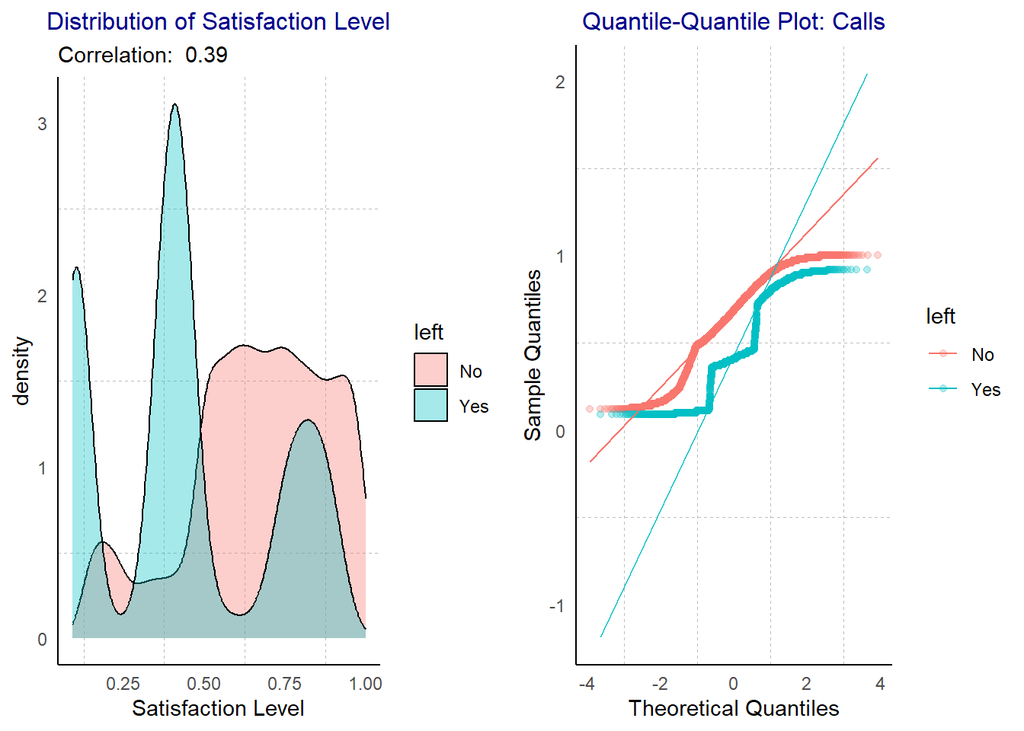

**Evaluation**

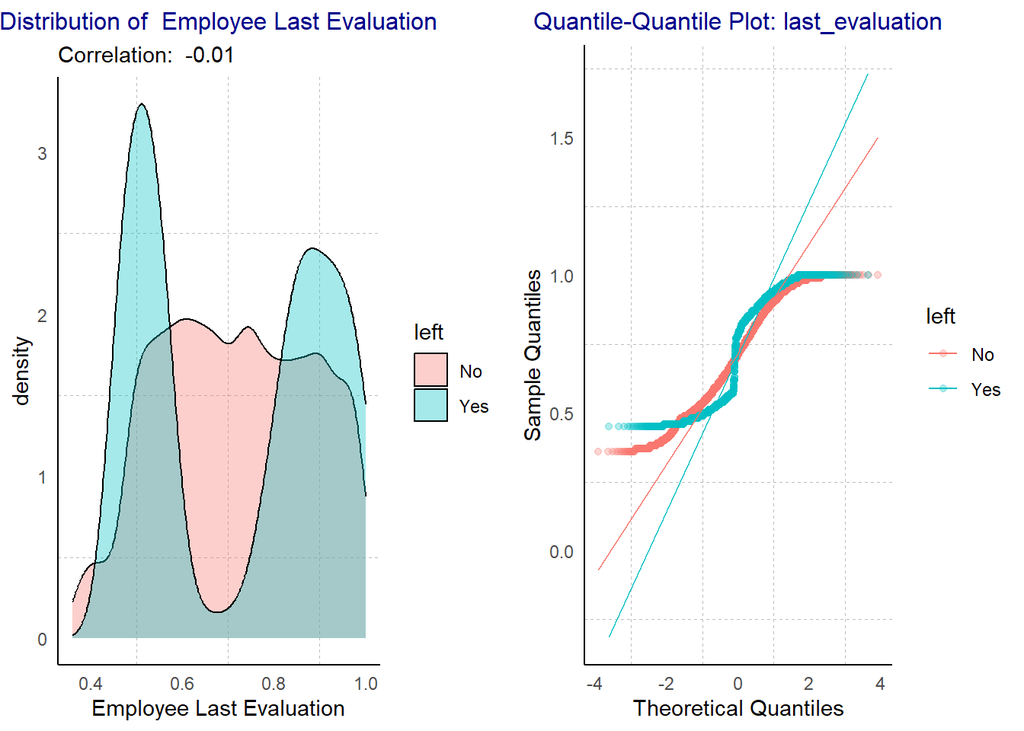

**Hours Worked**

[figure not shown]

**Employee tenure**

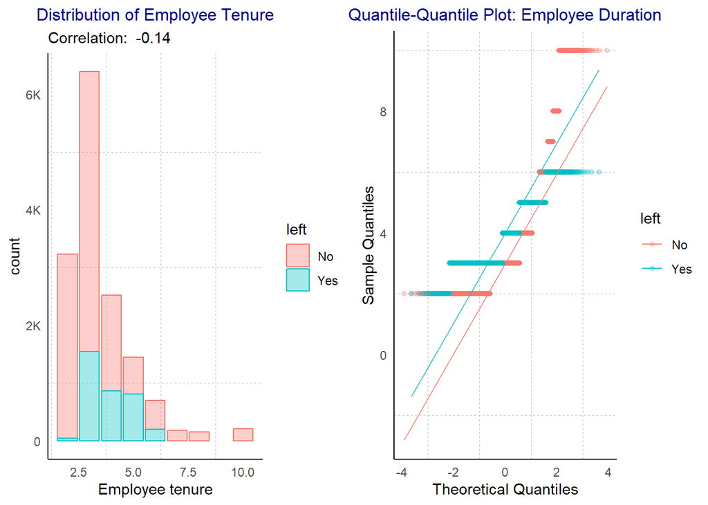

**Projects**

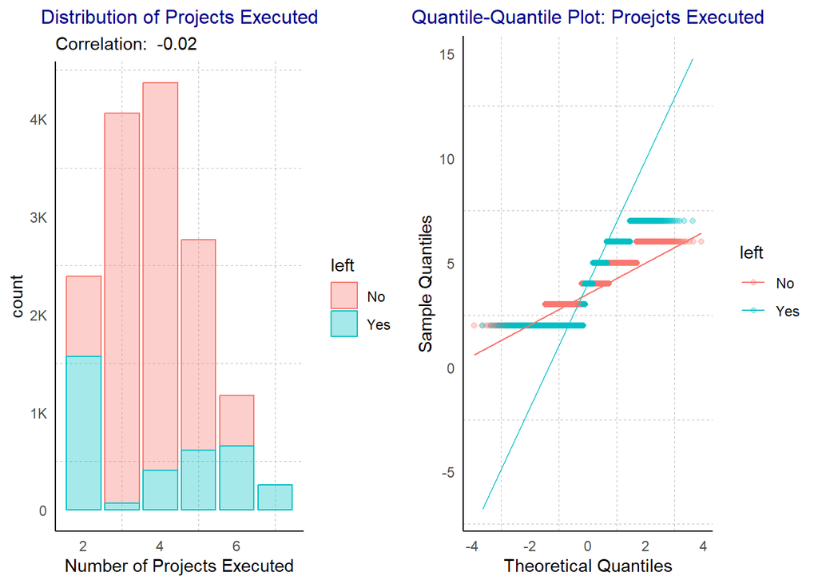

### Predictor Variable: Categorical

**Department**

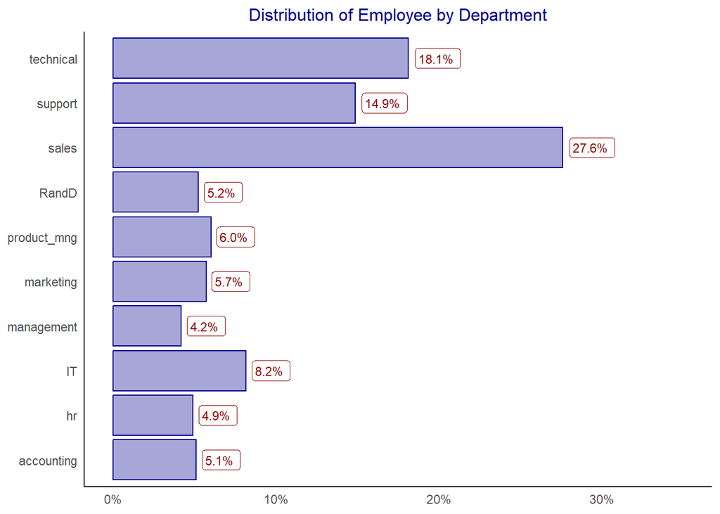

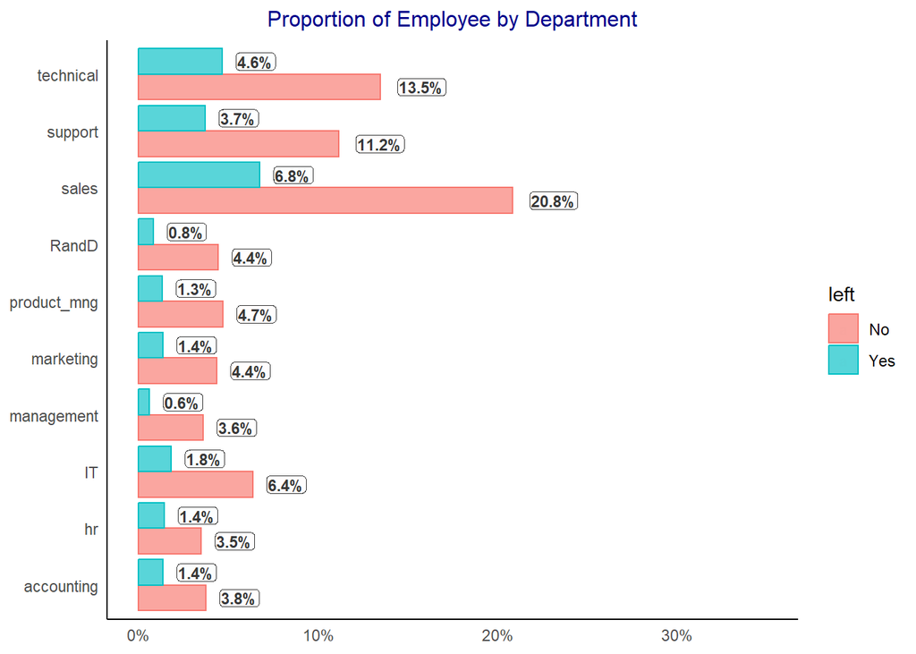

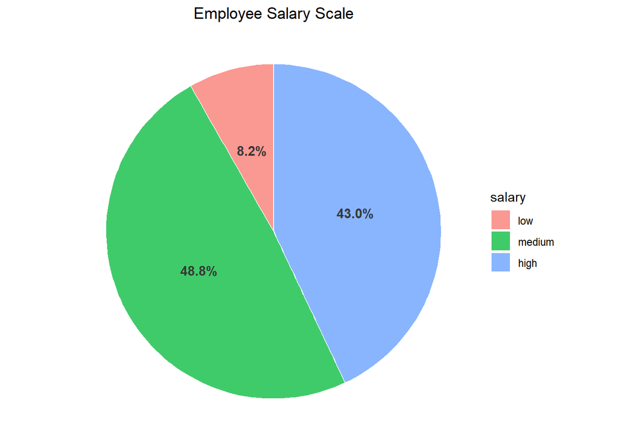

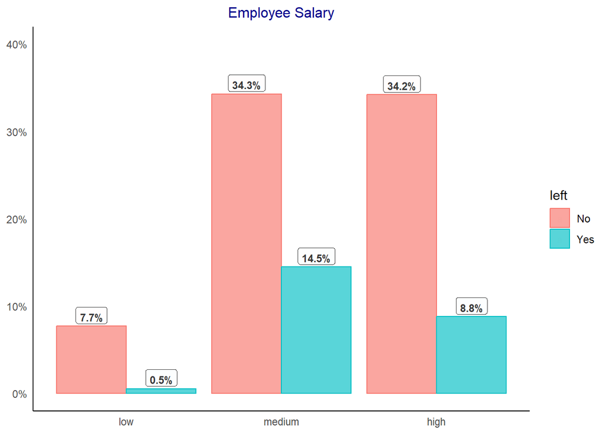

**Growth**

[figure not shown]

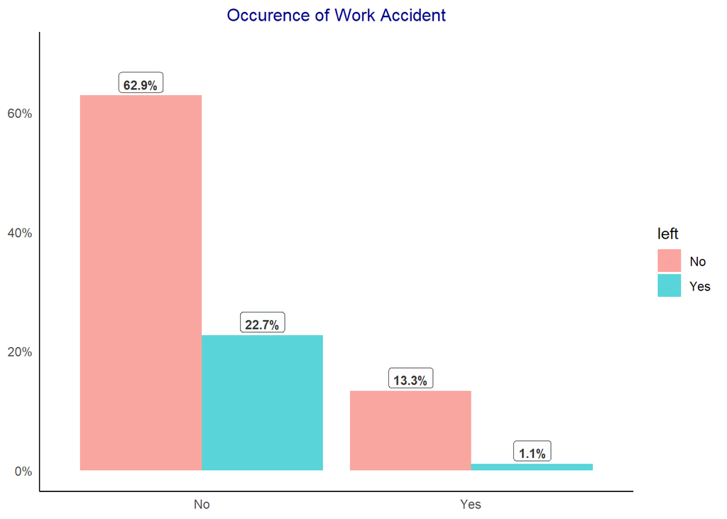

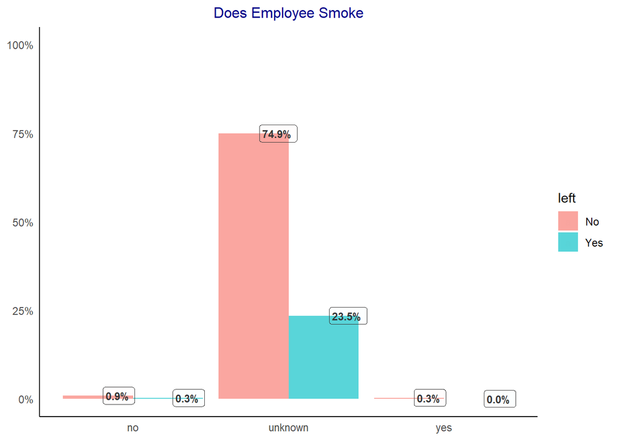

## Correlation Analysis

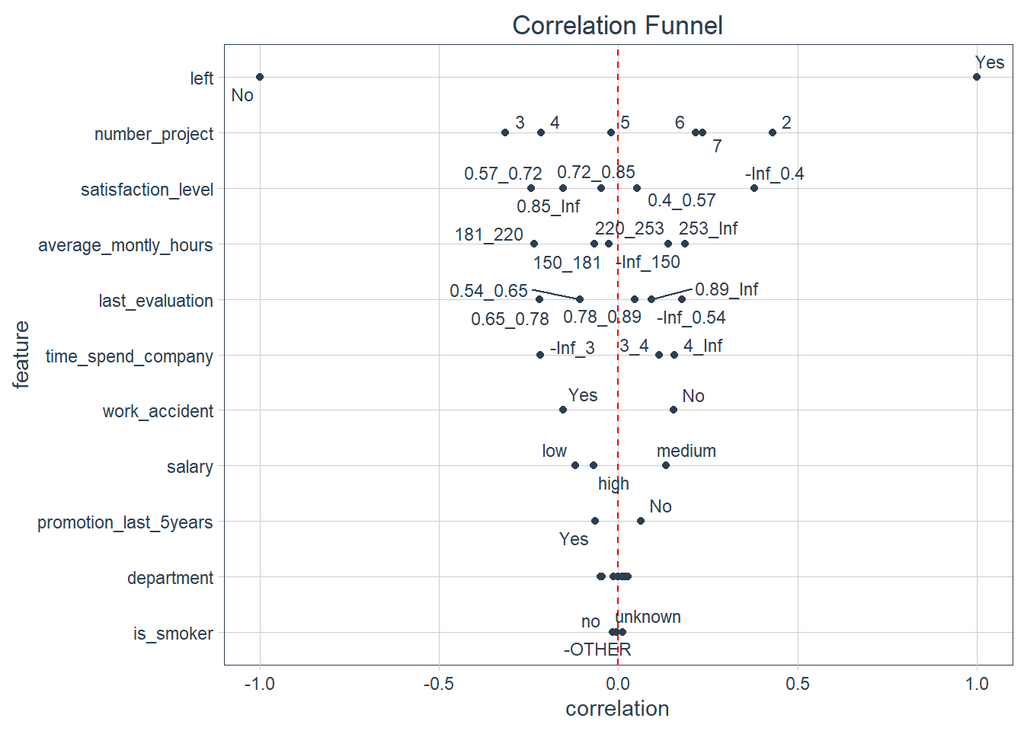

We found that employee attrition is linked to the number of projects they are engaged in. When employees are handling two projects or fewer, there is an increased likelihood of them leaving the organization. Conversely, when employees are juggling more than six projects, the risk of attrition also rises. Therefore, it is crucial for the company to strike a balance and aim to involve employees in the range of 3-4 projects. This optimized project engagement level enhances the chances of retaining valuable talent.

Another significant finding from our analysis is that employee satisfaction plays a pivotal role in attrition rates. Employees with a satisfaction level below 0.4 are more prone to leave the organization. This highlights the criticality of continuously measuring and addressing employee satisfaction levels to create a conducive and fulfilling work environment.

## Model Building

To identify the best-performing model, we employed a repeated measure ANOVA model, meticulously tuning each candidate model. Below are the summary of the model performance result:

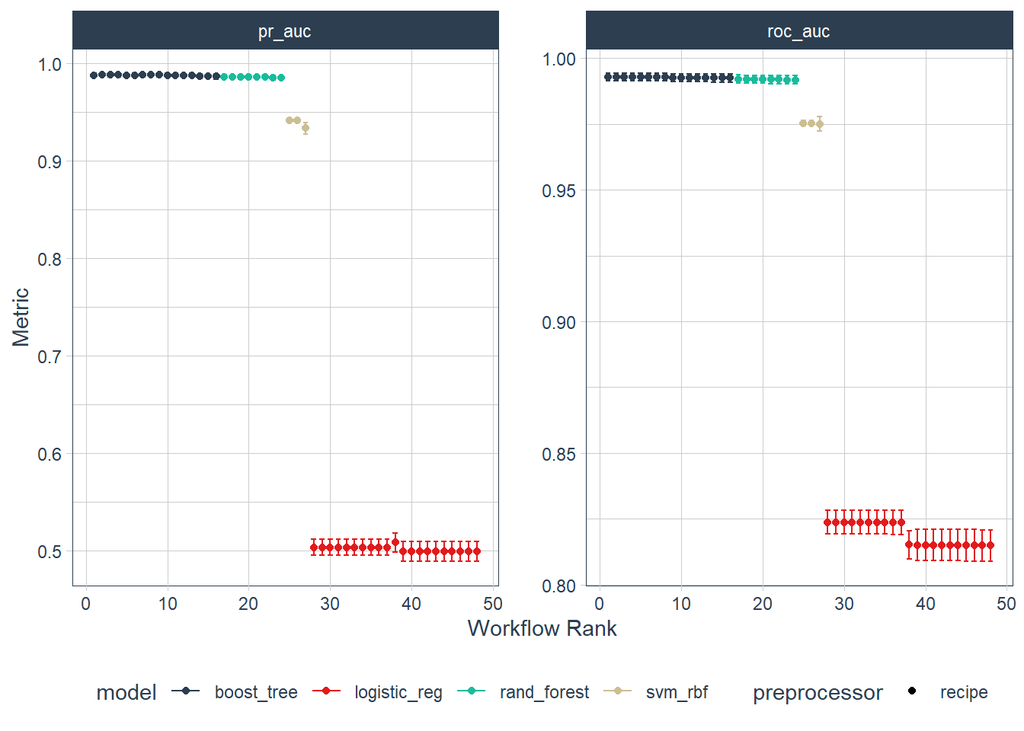

| model | wflow_id | .config | .metric | Rsquare | std_err | rank |
| --- | --- | --- | --- | --- | --- | --- |
| boost_tree | recip_adasyn_lightgbm | Preprocessor1_Model03 | pr_auc | 0.988 | 0.001 | 1 |
| boost_tree | recip_smote_lightgbm | Preprocessor1_Model09 | pr_auc | 0.988 | 0.001 | 2 |
| boost_tree | recip_rose_lightgbm | Preprocessor1_Model09 | pr_auc | 0.988 | 0.001 | 3 |
| boost_tree | recip_adasyn_lightgbm | Preprocessor1_Model09 | pr_auc | 0.988 | 0.001 | 4 |
| boost_tree | recip_smote_lightgbm | Preprocessor1_Model03 | pr_auc | 0.988 | 0.001 | 5 |
| boost_tree | recip_rose_lightgbm | Preprocessor1_Model03 | pr_auc | 0.988 | 0.001 | 6 |
| boost_tree | recip_adasyn_lightgbm | Preprocessor1_Model12 | pr_auc | 0.988 | 0.001 | 7 |
| boost_tree | recip_adasyn_lightgbm | Preprocessor1_Model06 | pr_auc | 0.988 | 0.001 | 8 |
| boost_tree | recip_adasyn_lightgbm | Preprocessor1_Model10 | pr_auc | 0.988 | 0.001 | 9 |
| boost_tree | recip_rose_lightgbm | Preprocessor1_Model10 | pr_auc | 0.988 | 0.001 | 10 |

### Ensemble Modelling

In this project, we focused on creating an ensemble of models to enhance predictive performance. Through meticulous experimentation and model combinations, we successfully identified the most effective model ensemble, which yielded remarkable results.

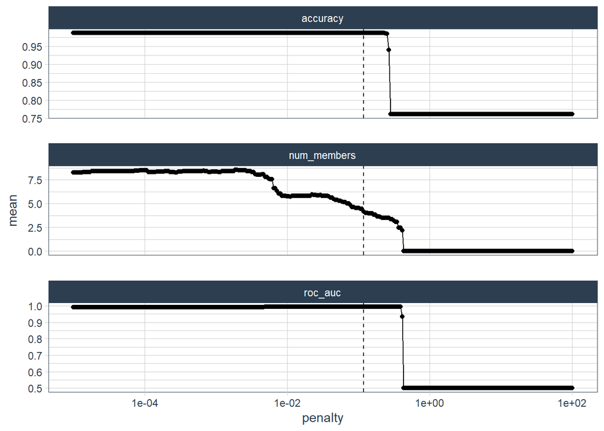

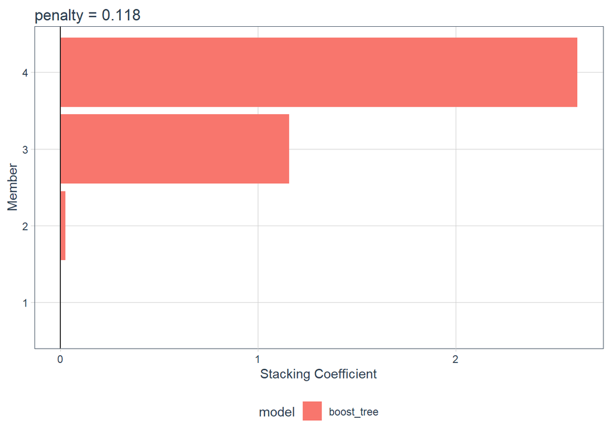

### Model Diagnostics

[output not shown]

Model Performance on Test dataset

| .metric | .estimator | .estimate |
| --- | --- | --- |
| accuracy | binary | 0.990 |
| roc_auc | binary | 0.995 |
| pr_auc | binary | 0.992 |
| average_precision | binary | 0.992 |

Check it out

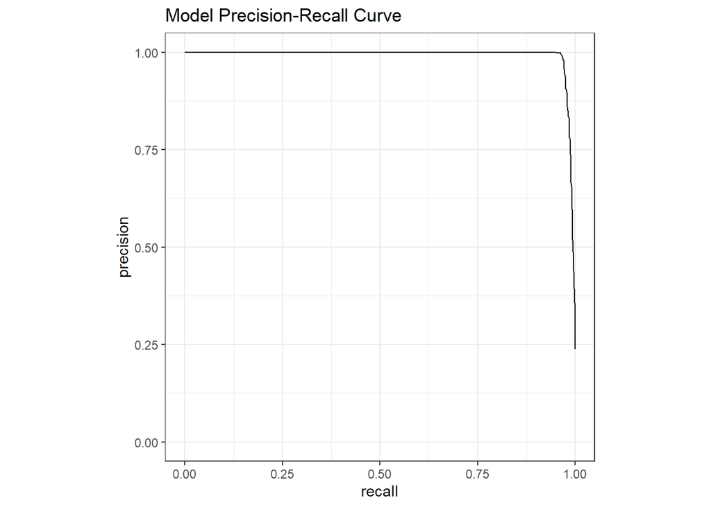

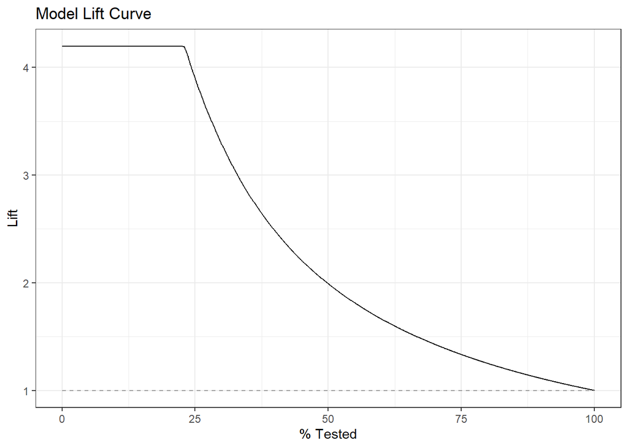

## Model Explaination

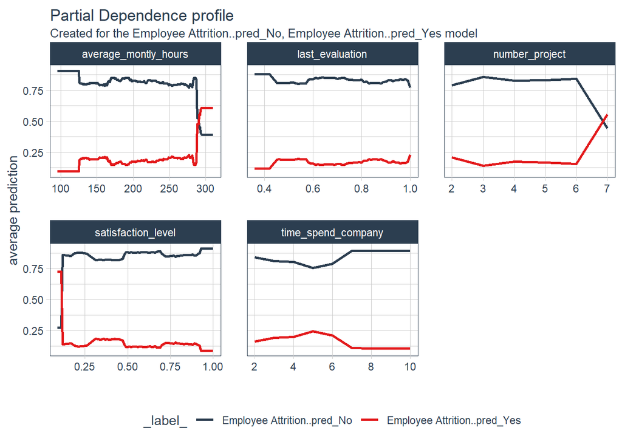

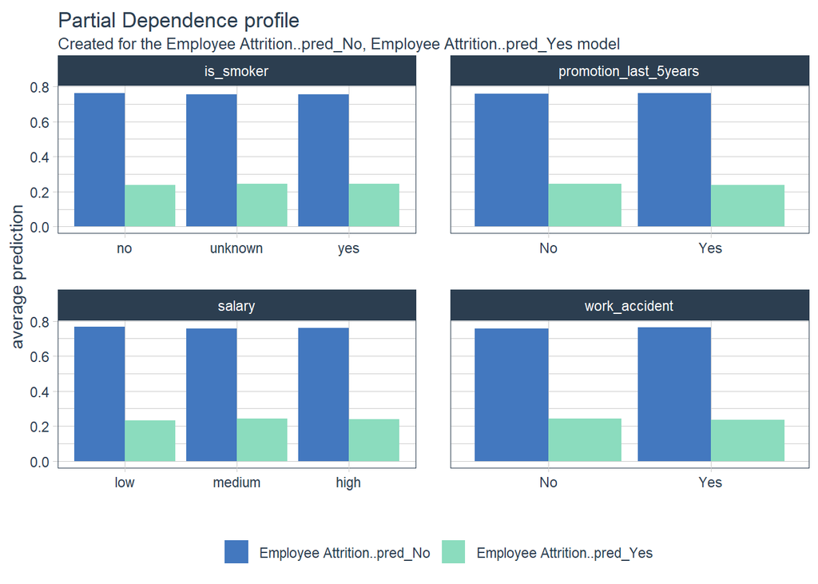

## Conclusion

These insights carry significant implications for our business. To mitigate employee attrition, we should focus on maintaining an optimal project engagement level for each employee, ensuring they are neither overwhelmed nor underutilized. Prioritizing employee satisfaction and promptly addressing any issues that arise can contribute to higher retention rates. Additionally, balancing workload expectations and refining the performance evaluation process may further improve employee retention and overall organizational success. As an HR team, understanding these correlations empowers us to implement targeted strategies to reduce attrition and cultivate a more engaged and stable workforce.

Implications for the Business:

These insights have important implications for our business and employee retention strategies:

Tailored Project Allocation: HR managers should focus on allocating projects strategically, considering individual employees’ capacities and workload preferences. Encouraging employees to handle an appropriate number of projects can boost job satisfaction and reduce attrition risk.

Employee Well-being and Satisfaction Initiatives: The organization should invest in employee well-being programs, regular feedback mechanisms, and supportive management practices to enhance employee satisfaction. Addressing concerns and fostering a positive work culture will contribute to higher retention rates.

Workload Management: It is essential to monitor and manage employee work hours effectively. Striking a balance between productivity and avoiding burnout is crucial. HR can collaborate with managers to ensure workload distribution aligns with employees’ preferences and capabilities.

Predictive Attrition Analysis: Building on this correlation analysis, we can develop predictive models to forecast potential attrition risks. Such models can help HR proactively identify employees at higher risk of leaving, allowing for timely intervention and personalized retention strategies.

In conclusion, by leveraging these insights, we can make informed decisions and implement targeted strategies to mitigate employee attrition. A focused approach to project allocation, employee satisfaction, and workload management will contribute to a more engaged and committed workforce, ultimately benefiting the organization’s overall performance and stability.